# Proyecto Final Coderhouse

Análisis de datos de la Libreria Casa de Papel

Augusto Barchi

2023-11-10

### **Introducción:**

##### Este proyecto se centra en el análisis exhaustivo de datos obtenidos de la libreria llamada “La casa de Papel”, que utilizando el lenguaje de programación R, conocido por su eficacia en manipulación y visualización de datos, desde la importación hasta la generación de visualizaciones informativas. Nos enfocaremos en descubrir patrones, tendencias y relaciones en los conjuntos de datos, utilizando métodos estadísticos y visualizaciones. Este proyecto no solo busca mostrar las capacidades de R en el análisis de datos, sino también proporcionar una base sólida para la toma de decisiones informadas en diversos contextos.

```
## # A tibble: 6 × 20
##      Id Fecha_orden         Prioridad Cantidad Ventas Descuento Modo_envio
##   <dbl> <dttm>              <chr>        <dbl>  <dbl>     <dbl> <chr>
## 1     3 2010-10-13 00:00:00 Baja             6  443.       0.04 Aereo regular
## 2     6 2012-02-20 00:00:00 Regular          2   11.1      0.01 Aereo regular
## 3    32 2011-07-15 00:00:00 Alta            15  274.       0.04 Aereo regular
## 4    32 2011-07-15 00:00:00 Alta            26 4733.       0.07 Aereo regular
## 5    32 2011-07-15 00:00:00 Alta            24 3186.       0.09 Terrestre
## 6    32 2011-07-15 00:00:00 Alta            23  276.       0.04 Aereo regular
## # ℹ 13 more variables: Margen <dbl>, Utilidad <dbl>, Precio_venta <dbl>,
## #   Precio_costo <dbl>, Costo_envio <dbl>, Nombre_cliente <chr>, Region <chr>,
## #   Segmento <chr>, Categoria <chr>, Subcategoria <chr>, Producto <chr>,
## #   Empaque <chr>, Fecha_envio <dttm>
```

```
##        Id         Fecha_orden                      Prioridad
##  Min.   :    3   Min.   :2009-01-01 00:00:00.00   Length:8399
##  1st Qu.:15012   1st Qu.:2009-12-20 00:00:00.00   Class :character
##  Median :29857   Median :2010-12-17 00:00:00.00   Mode  :character
##  Mean   :29965   Mean   :2010-12-25 00:40:58.57
##  3rd Qu.:44596   3rd Qu.:2012-01-01 12:00:00.00
##  Max.   :59973   Max.   :2012-12-30 00:00:00.00
##     Cantidad         Ventas            Descuento        Modo_envio
##  Min.   : 1.00   Min.   :     3.96   Min.   :0.00000   Length:8399
##  1st Qu.:13.00   1st Qu.:   250.26   1st Qu.:0.02000   Class :character
##  Median :26.00   Median :   793.84   Median :0.05000   Mode  :character
##  Mean   :25.57   Mean   :  3236.71   Mean   :0.04967
##  3rd Qu.:38.00   3rd Qu.:  3096.05   3rd Qu.:0.08000
##  Max.   :50.00   Max.   :139991.57   Max.   :0.25000
##      Margen          Utilidad         Precio_venta       Precio_costo
##  Min.   :0.3500   Min.   :    0.84   Min.   :    1.55   Min.   :   0.99
##  1st Qu.:0.4000   1st Qu.:  100.35   1st Qu.:   12.26   1st Qu.:   6.48
##  Median :0.4500   Median :  320.98   Median :   39.96   Median :  20.99
##  Mean   :0.4494   Mean   : 1377.56   Mean   :  163.64   Mean   :  89.35
##  3rd Qu.:0.5000   3rd Qu.: 1301.80   3rd Qu.:  157.50   3rd Qu.:  85.99
##  Max.   :0.5500   Max.   :51787.82   Max.   :13566.04   Max.   :6783.02
##   Costo_envio     Nombre_cliente        Region            Segmento
##  Min.   :  0.49   Length:8399        Length:8399        Length:8399
##  1st Qu.:  3.30   Class :character   Class :character   Class :character
##  Median :  6.07   Mode  :character   Mode  :character   Mode  :character
##  Mean   : 12.84
##  3rd Qu.: 13.99
##  Max.   :164.73
##   Categoria         Subcategoria         Producto           Empaque
##  Length:8399        Length:8399        Length:8399        Length:8399
##  Class :character   Class :character   Class :character   Class :character
##  Mode  :character   Mode  :character   Mode  :character   Mode  :character
##
##
##
##   Fecha_envio
##  Min.   :2009-01-02 00:00:00.00
##  1st Qu.:2009-12-22 12:00:00.00
##  Median :2010-12-18 00:00:00.00
##  Mean   :2010-12-27 01:28:48.63
##  3rd Qu.:2012-01-03 12:00:00.00
##  Max.   :2012-12-30 00:00:00.00
```

### Análisis de Datos

##### Proporciona resúmenes estadísticos separados para las variables categóricas y numéricas en el conjunto de datos, ofreciendo una comprensión rápida de la distribución y características de ambas tipos de variables.

#### Resumen de Variables Categóricas

```
##   Prioridad          Categoria         Subcategoria
##  Length:8399        Length:8399        Length:8399
##  Class :character   Class :character   Class :character
##  Mode  :character   Mode  :character   Mode  :character
```

#### Resumen de Variables Numéricas

```
##     Cantidad         Ventas              Margen          Utilidad
##  Min.   : 1.00   Min.   :     3.96   Min.   :0.3500   Min.   :    0.84
##  1st Qu.:13.00   1st Qu.:   250.26   1st Qu.:0.4000   1st Qu.:  100.35
##  Median :26.00   Median :   793.84   Median :0.4500   Median :  320.98
##  Mean   :25.57   Mean   :  3236.71   Mean   :0.4494   Mean   : 1377.56
##  3rd Qu.:38.00   3rd Qu.:  3096.05   3rd Qu.:0.5000   3rd Qu.: 1301.80
##  Max.   :50.00   Max.   :139991.57   Max.   :0.5500   Max.   :51787.82
##    Descuento        Precio_venta       Precio_costo      Costo_envio
##  Min.   :0.00000   Min.   :    1.55   Min.   :   0.99   Min.   :  0.49
##  1st Qu.:0.02000   1st Qu.:   12.26   1st Qu.:   6.48   1st Qu.:  3.30
##  Median :0.05000   Median :   39.96   Median :  20.99   Median :  6.07
##  Mean   :0.04967   Mean   :  163.64   Mean   :  89.35   Mean   : 12.84
##  3rd Qu.:0.08000   3rd Qu.:  157.50   3rd Qu.:  85.99   3rd Qu.: 13.99
##  Max.   :0.25000   Max.   :13566.04   Max.   :6783.02   Max.   :164.73
```

##### Primeramente se estudia la información sobre las dimensiones de un conjunto de datos y, si hay valores faltantes, también informa sobre la cantidad total de valores faltantes y la cantidad de valores faltantes por columna, para luego si estudio.

```
## Número de Filas: 8399
## Número de Columnas: 20
## No hay datos NA en el dataset.
```

### Agrupar la variable Region y calcular una estadística resumen

##### Se selecciona solo las columnas de interés del conjunto de datos original y se realiza operaciones de manipulación y resumen de datos, proporcionando estadísticas específicas sobre las ventas y la utilidad para cada región del conjunto de datos.

```
## # A tibble: 7 × 3
##   Region    Ventas_promedio Utilidad_total
##   <chr>               <dbl>          <dbl>
## 1 Argentina           3065.       2401755.
## 2 Bolivia             3275.       2754555.
## 3 Chile               3481.       1144310.
## 4 Colombia            3433.       1592234.
## 5 Ecuador             2643.         88165.
## 6 Paraguay            3040.       2206732.
## 7 Peru                3469.       1382352.
```

### Suma de Ventas Filtrado y Agrupado por Categoría y Subcategoría

##### Se realiza una operación de filtrado y agrupación en un conjunto de datos para Imprimir en la consola el conjunto de datos resultante, que contiene la suma total de las ventas agrupadas por “Categoria” y “Subcategoria

```
## # A tibble: 7 × 3
## # Groups:   Categoria [3]
##   Categoria            Subcategoria        Ventas_totales
##   <chr>                <chr>                        <dbl>
## 1 Elementos de oficina Carpetas                   281028.
## 2 Elementos de oficina Tijeras                     34365.
## 3 Muebles              Librerias                  335896.
## 4 Muebles              Mesas                      334905.
## 5 Muebles              Tapetes                    119767.
## 6 Tecnologia           Copiadoras                 750087.
## 7 Tecnologia           Maquinas de oficina        804015.
```

### Ventas por Region

##### Se genera un gráfico de barras que muestra las ventas promedio por región, utilizando colores graduados para representar la magnitud de las ventas. Este gráfico proporciona una visualización rápida y efectiva de las diferencias en las ventas entre regiones.

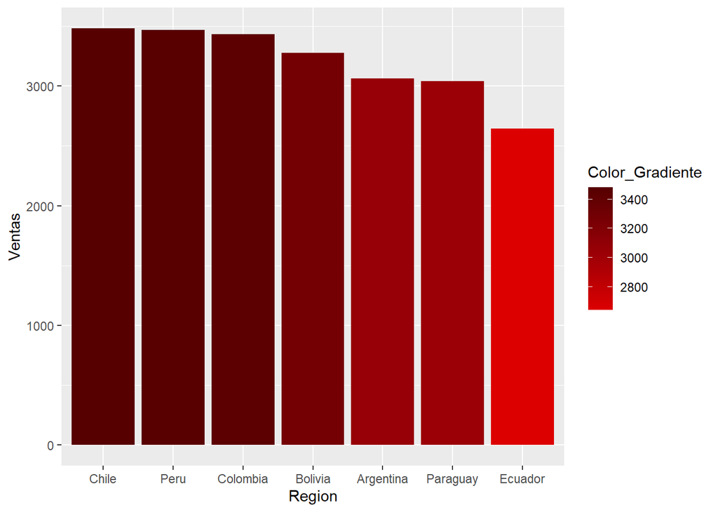

### Ventas por Categoría

##### Se genera un gráfico de barras que muestra las ventas promedio por categoría, utilizando colores graduados para representar la magnitud de las ventas. Este gráfico proporciona una visualización rápida y efectiva de las diferencias en las ventas entre categorías.

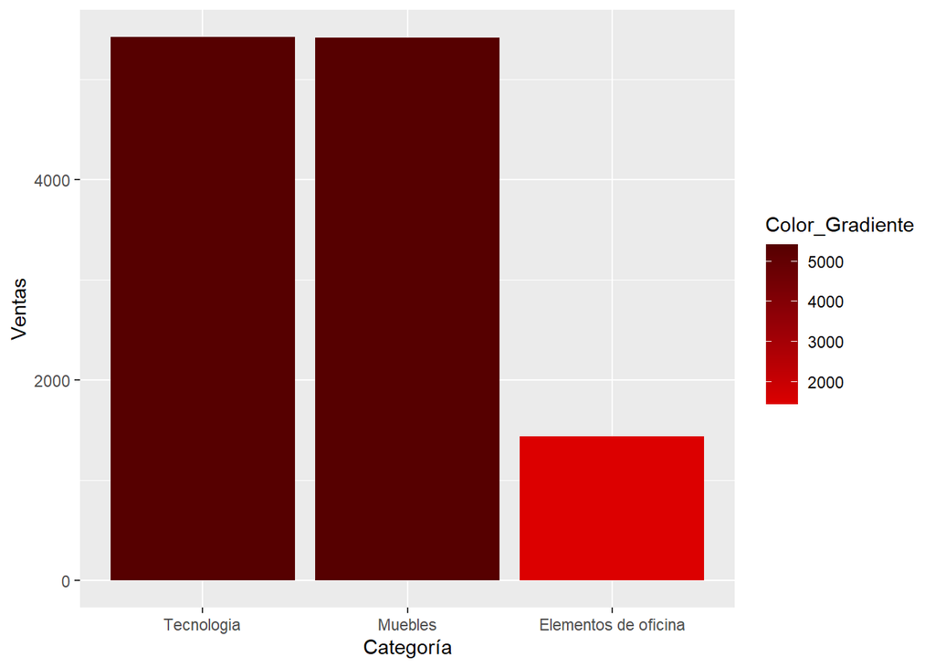

### Análisis de Datos PCA

##### Se muestra un resumen del PCA, incluyendo descriptores estadísticos, la proporción de varianza explicada por cada componente principal y la varianza acumulada.

```
##     Cantidad       Ventas    Descuento       Margen     Utilidad Precio_venta
## 2.557173e+01 3.236708e+03 4.967139e-02 4.494214e-01 1.377557e+03 1.636364e+02
## Precio_costo
## 8.934626e+01
```

```
##     Cantidad       Ventas    Descuento       Margen     Utilidad Precio_venta
## 1.448107e+01 6.494909e+03 3.182302e-02 6.034511e-02 2.844247e+03 5.254159e+02
## Precio_costo
## 2.903544e+02
```

```
##                      PC1        PC2           PC3           PC4         PC5
## Cantidad      0.05514665  0.7696054 -0.2436965842  0.0488692965 -0.58551221
## Ventas        0.50560688  0.2651283 -0.0464888157 -0.0009817862  0.40662546
## Descuento    -0.01276122 -0.1057565 -0.5883241766 -0.8005746952  0.03798783
## Margen        0.04232535  0.1597382  0.7689065977 -0.5950072355 -0.15649132
## Utilidad      0.49953600  0.2859186  0.0202925562 -0.0294991921  0.42048046
## Precio_venta  0.49723547 -0.3255939 -0.0005039341  0.0169568987 -0.37478605
## Precio_costo  0.49253114 -0.3360847 -0.0263823868  0.0387251368 -0.38552584
##                      PC6           PC7
## Cantidad     -0.00807699 -0.0005752777
## Ventas        0.60800550  0.3699885776
## Descuento    -0.01032803 -0.0076018760
## Margen        0.05400043  0.0059760673
## Utilidad     -0.59117727 -0.3756833565
## Precio_venta -0.38489666  0.5982037134
## Precio_costo  0.36000744 -0.6033481188
```

```
## Importance of components:
##                           PC1    PC2    PC3    PC4     PC5    PC6     PC7
## Standard deviation     1.7844 1.1175 1.0062 0.9948 0.74085 0.1152 0.05317
## Proportion of Variance 0.4549 0.1784 0.1446 0.1414 0.07841 0.0019 0.00040
## Cumulative Proportion  0.4549 0.6333 0.7779 0.9193 0.99770 0.9996 1.00000
```

##### Se crea un gráfico de dispersión para visualizar las observaciones en el espacio bidimensional definido por los dos primeros componentes principales. Este gráfico permite visualizar patrones y relaciones entre las observaciones en términos de las nuevas variables (componentes principales) generadas por el PCA.

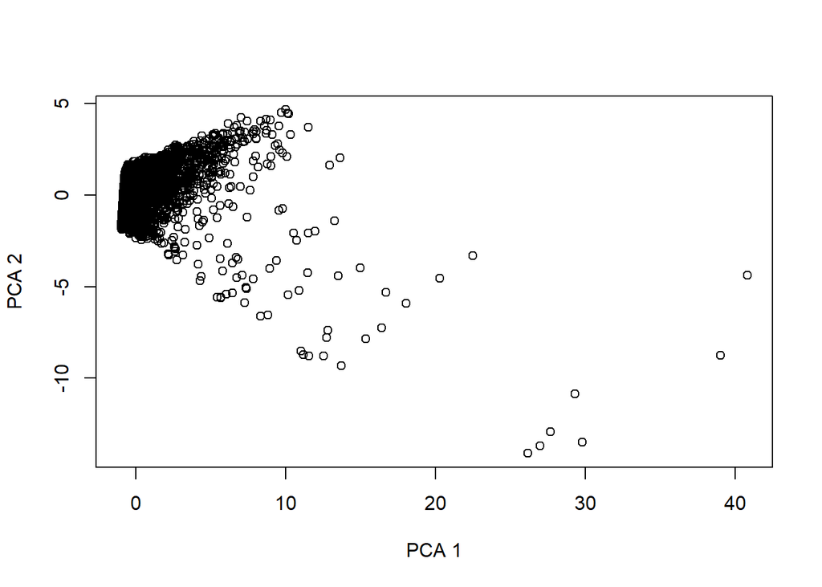

### Scree Plot

##### Proporciona visualizaciones importantes para entender la distribución de la varianza en los componentes principales, especialmente a través de los gráficos de barras y el Scree Plot. Además, crea un data frame con las coordenadas de las observaciones en el espacio bidimensional del PCA y agrega información categórica para representar los datos por región.

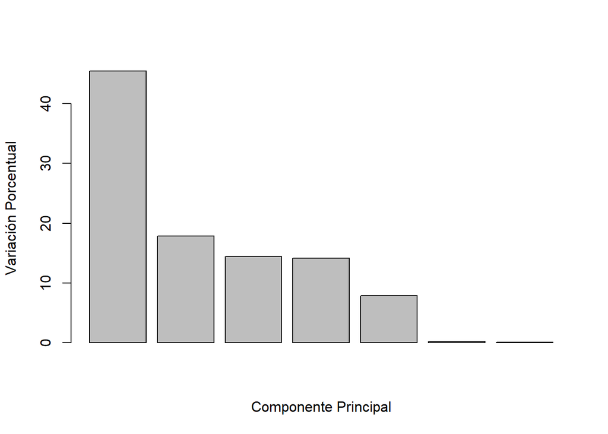

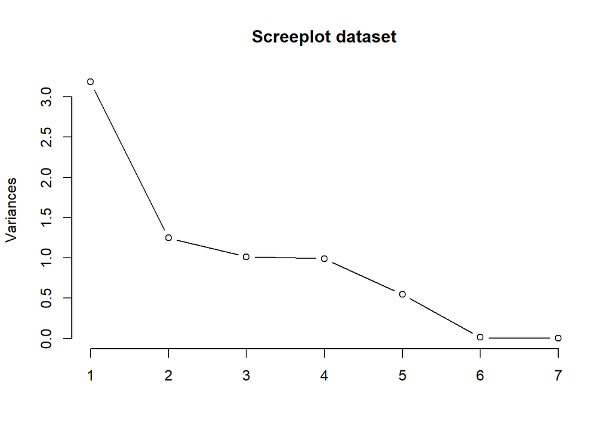

### Gráfico PCA por País

##### Se genera un gráfico de dispersión que muestra la distribución de las observaciones en el espacio bidimensional del PCA, con colores distintivos para cada región. Este tipo de gráfico facilita la identificación de patrones o agrupaciones en los datos en función de las nuevas dimensiones obtenidas mediante el PCA.

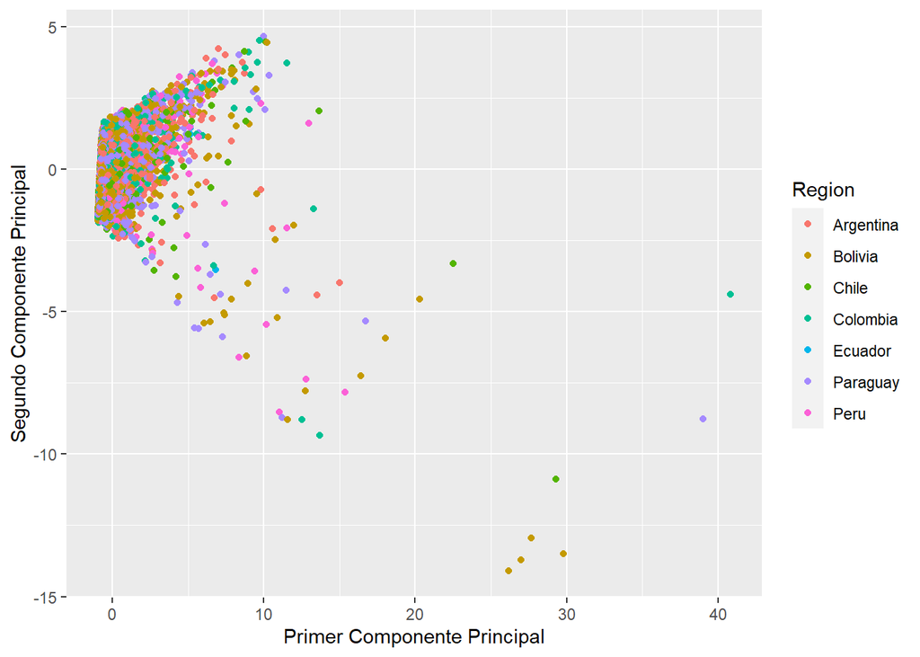

### Gráfico de Análisis de Componentes Principales

##### Se genera un gráfico de biplot que proporciona información sobre la distribución de las observaciones y la contribución de las variables originales en el espacio bidimensional definido por los dos primeros componentes principales del PCA. La coloración por región facilita la identificación de patrones y agrupaciones en los datos.

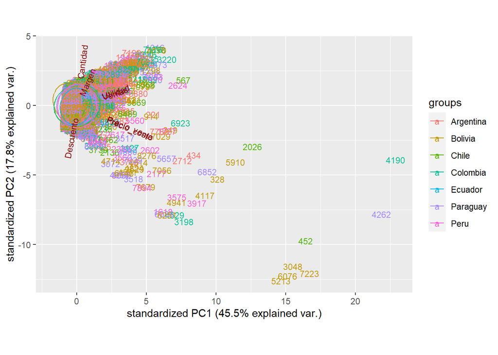